# Advanced Empirical Finance: Topics and Data Science

The SDF, the efficient frontier and the CAPM

Stefan Voigt

University of Copenhagen and Danish Finance Institute (DFI)

Spring 2027

## From portfolios to prices

- Lectures 2 to 5: given expected returns, **which portfolio** should an investor hold?
- Now the other way round: given how investors choose, **which expected returns** do assets earn?
- Both questions meet in the same object: the efficient (tangency) portfolio

**Today:** one equation that prices every asset, its link to the efficient frontier, and the CAPM as its best-known special case

# The stochastic discount factor

## Whiteboard: the fundamental equation

An investor with utility $u(c)$ can buy an asset at price $p_t$ that pays $x_{t+1}$ next period. When is she indifferent about buying a little more? (Cochrane, 2005, chapter 1)

$$p_t = E_t\big[m_{t+1}\,x_{t+1}\big] \qquad m_{t+1} = \beta\,\frac{u'(c_{t+1})}{u'(c_t)}$$

- For returns: $1 = E[mR]$; the risk-free rate is $R_f = 1/E[m]$; for excess returns: $0 = E[mR^e]$
- Expected excess returns come from the covariance with $m$:

$$E[R^e_i] = -R_f\,\text{Cov}(m, R^e_i)$$

- An asset that pays off in bad times, when $m$ is high, insures the investor and earns a low return

## Whiteboard: the SDF and the efficient frontier

Which $m$ prices $N$ given assets, and how volatile must it be? (Cochrane, 2005, chapters 5 and 6)

- An SDF that is linear in returns, $m = a + b'R$, prices the assets if and only if the portfolio with weights proportional to $b$ is **mean-variance efficient**: the tangency portfolio of lecture 2 is an SDF
- $|E[R^e]| \leq \frac{\sigma(m)}{E(m)}\,\sigma(R^e)$ for every excess return, so

$$\frac{\sigma(m)}{E(m)} \geq \max \text{ Sharpe ratio}$$

- This is the **Hansen-Jagannathan bound** (Hansen & Jagannathan, 1991): the higher the best attainable Sharpe ratio, the more volatile any SDF must be

## The bound in the data

- The market and the ten Fama-French industry portfolios, 1960–2025: the market alone has a Sharpe ratio of 0.46 a year, the tangency portfolio of all eleven 0.67
- So any SDF that prices these assets has $\sigma(m)/E(m) \geq$ 0.67 a year
- With $m = \beta\,u'(c_{t+1})/u'(c_t)$ and power utility, $\sigma(m) \approx \gamma\,\sigma(\Delta c)$. Consumption growth varies by about 1–2% a year, so $\gamma$ must be implausibly large: the **equity premium puzzle** (Mehra & Prescott, 1985)

# The CAPM

## Whiteboard: the CAPM as an SDF

Suppose the market portfolio is mean-variance efficient. What does that imply for $m$, and for expected returns?

$$m = a - b\,R_m \qquad \Longleftrightarrow \qquad E[R^e_i] = \beta_i\,E[R^e_m], \qquad \beta_i = \frac{\text{Cov}(R_i, R_m)}{\text{Var}(R_m)}$$

- The **security market line**: only the covariance with the market earns a premium; idiosyncratic risk does not (Sharpe, 1964; Lintner, 1965)
- In a regression $R^e_{i,t} = \alpha_i + \beta_i R^e_{m,t} + \varepsilon_{i,t}$, the CAPM says $\alpha_i = 0$ for every asset

## Do high-beta industries earn more?

Ten industries, 1960–2025: do the industries with high market betas have higher average excess returns?

- Yes clearly
- A little
- No relation
- The opposite

## Betas and alphas of ten industries

- R
- Python

```r
capm <- industries |>
  nest(data = -industry) |>
  mutate(
    fit = map(data, \(d) summary(lm(ret_excess ~ mkt_excess, data = d))$coefficients),
    alpha = map_dbl(fit, \(f) f["(Intercept)", "Estimate"]),
    t_alpha = map_dbl(fit, \(f) f["(Intercept)", "t value"]),
    beta = map_dbl(fit, \(f) f["mkt_excess", "Estimate"]),
    mean = map_dbl(data, \(d) mean(d$ret_excess))
  ) |>
  select(industry, alpha, t_alpha, beta, mean)
```

```python
factors_ff3_monthly = pl.read_parquet("data/factors_ff3_monthly.parquet")
industries = (
    pl.read_parquet("data/industries_ff_monthly.parquet")
    .unpivot(index="date", variable_name="industry", value_name="ret")
    .join(factors_ff3_monthly, on="date")
    .with_columns(ret_excess=pl.col("ret") - pl.col("risk_free"))
)

rows = []
for (industry,), data in industries.group_by("industry"):
    fit = smf.ols("ret_excess ~ mkt_excess", data=data.to_pandas()).fit()
    rows.append({"industry": industry, "alpha": fit.params["Intercept"],
                 "t_alpha": fit.tvalues["Intercept"], "beta": fit.params["mkt_excess"],
                 "mean": data["ret_excess"].mean()})
capm = pl.DataFrame(rows).sort("industry")
```

`industries` holds the monthly excess returns of the ten Fama-French industries, with the market excess return from `factors_ff3_monthly.parquet`

## The security market line

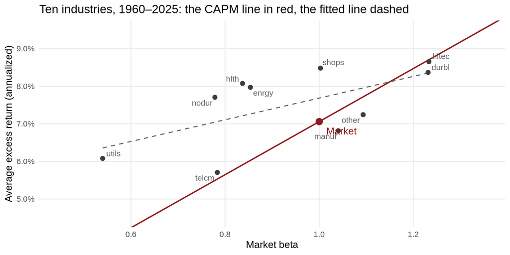

## Pricing with the CAPM’s SDF

- Take $m = 1 - b\,(R^e_m - E[R^e_m])$. The pricing error of asset $i$ is $E[m R^e_i] = E[R^e_i] - b\,\text{Cov}(R^e_m, R^e_i)$
- $b = 0$: a risk-neutral investor, the errors are the average excess returns. With the CAPM’s $b^*$, the market is priced exactly and the errors of the industries are their alphas

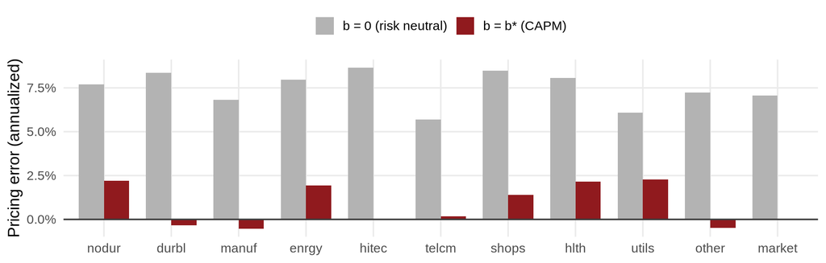

# Testing the CAPM

## Alphas

| Industry | Beta | Average excess return | Alpha (annualized) | t-statistic of alpha |
| --- | --- | --- | --- | --- |
| hitec | 1.23 | 8.7% | -0.1% | -0.04 |
| durbl | 1.23 | 8.4% | -0.3% | -0.16 |
| other | 1.09 | 7.2% | -0.5% | -0.55 |
| manuf | 1.04 | 6.8% | -0.5% | -0.70 |
| shops | 1.00 | 8.5% | 1.4% | 1.30 |
| enrgy | 0.85 | 8.0% | 1.9% | 0.98 |
| hlth | 0.84 | 8.1% | 2.2% | 1.61 |
| telcm | 0.78 | 5.7% | 0.2% | 0.13 |
| nodur | 0.78 | 7.7% | 2.2% | 2.10 |
| utils | 0.54 | 6.1% | 2.3% | 1.63 |

- Low-beta industries tend to have positive alphas, high-beta industries negative ones: the security market line is flatter than the CAPM says

## Whiteboard: the GRS test

Test all alphas at once, $H_0: \alpha_1 = \ldots = \alpha_N = 0$, from $T$ months of time-series regressions on the market

$$\text{GRS} = \frac{T - N - 1}{N}\,\frac{\hat\alpha'\hat\Sigma^{-1}\hat\alpha}{1 + \hat\mu_m^2/\hat\sigma_m^2} \sim F(N, T - N - 1)
\qquad
\hat\alpha'\hat\Sigma^{-1}\hat\alpha = \widehat{SR}^2_\text{market + assets} - \widehat{SR}^2_\text{market}$$

- $\hat\Sigma$ is the covariance matrix of the residuals (Gibbons, Ross & Shanken, 1989)
- The test asks lecture 2’s question: does adding the assets to the market raise the highest attainable Sharpe ratio?

## GRS for the ten industries

- R
- Python

```r
y <- industries_wide |> select(-date, -mkt_excess) |> as.matrix()
x <- industries_wide$mkt_excess
n_months <- nrow(y)
n_assets <- ncol(y)

fit <- lm(y ~ x)
alpha <- coef(fit)[1, ]
sigma_resid <- crossprod(residuals(fit)) / n_months
sharpe_market_2 <- mean(x)^2 / mean((x - mean(x))^2)

grs <- (n_months - n_assets - 1) / n_assets *
  as.numeric(t(alpha) %*% solve(sigma_resid, alpha)) / (1 + sharpe_market_2)
p_value <- 1 - pf(grs, n_assets, n_months - n_assets - 1)
```

```python
wide = (
    industries.pivot(on="industry", index="date", values="ret_excess")
    .join(factors_ff3_monthly.select("date", "mkt_excess"), on="date")
    .sort("date")
)
y = wide.drop("date", "mkt_excess").to_numpy()
x = wide["mkt_excess"].to_numpy()
n_months, n_assets = y.shape

design = np.column_stack([np.ones(n_months), x])
coef, *_ = np.linalg.lstsq(design, y, rcond=None)
alpha = coef[0]
residuals = y - design @ coef
sigma_resid = residuals.T @ residuals / n_months
sharpe_market_2 = x.mean() ** 2 / x.var()

grs = ((n_months - n_assets - 1) / n_assets
       * alpha @ np.linalg.solve(sigma_resid, alpha) / (1 + sharpe_market_2))
p_value = 1 - f_distribution.cdf(grs, n_assets, n_months - n_assets - 1)
```

GRS = 1.51, p-value 0.13: the ten industries do not reject the CAPM. The tangency portfolio raises the Sharpe ratio from 0.46 to 0.67, but over 792 months that is not enough evidence

## What else is wrong with the CAPM?

- **Power:** industries are similar to each other and to the market. Portfolios sorted on size and book-to-market have large CAPM alphas (Fama & French, 1993). Next lecture: all stocks, sorted on beta
- **A flat security market line:** low-beta stocks earn too much, high-beta stocks too little (Fama & French, 2004; Frazzini & Pedersen, 2014)
- **The market is unobservable:** a test of the CAPM tests the proxy, here the CRSP value-weighted index (Roll, 1977)
- **Betas move over time:** exercise 3 estimates them with rolling windows for every CRSP stock